# Research Worldwide Bureaucracy Indicators to help implement efficient public policies

INFO 526 - Summer 2024 - Final Project

This project aims to discover efficient public policies implementation through the analysis of bureaucracy indicators around the world

Author

Affiliation

Mohammad Rahat Helal

School of Information, University of Arizona

## Abstract

The available data on public sector employment globally suggests that it forms one of the significant job generators and seems necessary for any economy. Referring to Baig et al. (2021), the World Bank developed a dataset called “Worldwide Bureaucracy Indicators,” or WWBI, which consists of information on public and private sector income, employment, and employee wages further divided into sub-categories. Although the original dataset consists of more than 150 indicators of bureaucracy, the subset of that data is available for us to delve deeper into a few critical indicators for evaluating economic growth and policymaking. The dataset used for this project has nearly 20 such variables for all participating countries that help us answer a few questions. One of the starting points for this project is understanding the year-on-year trend of public sector employment across geographies and a possible comparison between them.

Furthermore, the focus is shifted to a single country or countries in the same region, and the rise or fall of employment trends through these years is assessed. A subset of bureaucracy indicators were utilized to visualize the trend over the years for specific countries. Based on the outcome, the following research will establish the reasons behind such situations, and help policymakers to work on policies accordingly. The next topic to be discussed is the relationship between the efficiency of public administration and income levels in various countries. The exercise analyzes underlying data and reviews whether efficiency relates to income groupings.

The next paragraphs emphasize on the two questions that were researched and the creation of plots to visualize the trends.

### Question 1:

Compare the different regions globally, research how has public sector employment changed over time? Pick up one country in a region and research if there are underlying factors for such changes?

### Question 2:

In context of public administration in different geographies, what is the relationship between income group and public administration efficiency?

### Visualization for Question 1

The visualizations created to address question 1 are shown below.

- Create the year-on-year trend graph for all geographies showing the Public Sector Employment as a share of Total Employment Over Time by regions in general and North America in particular.

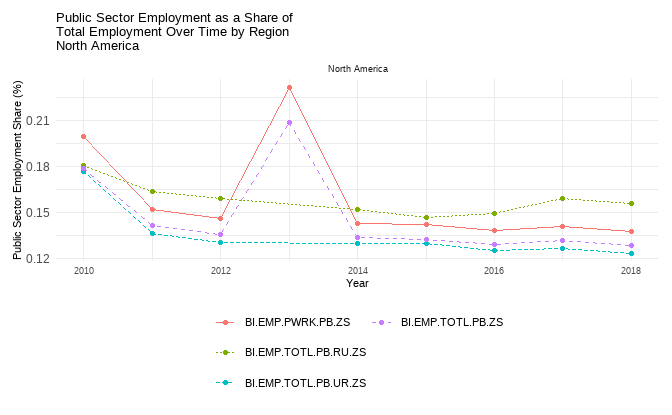

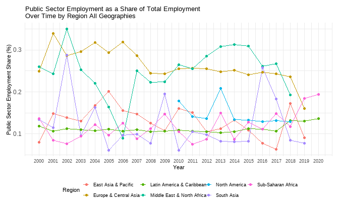

- Tested the use of world map background and show the same trend, but this plot does not deliver the intended meaning like the previous plot.

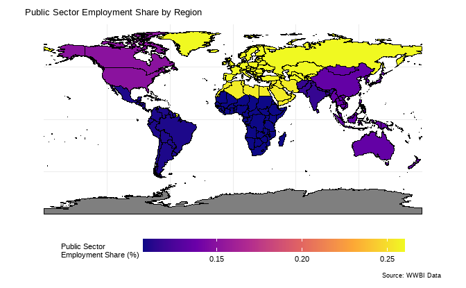

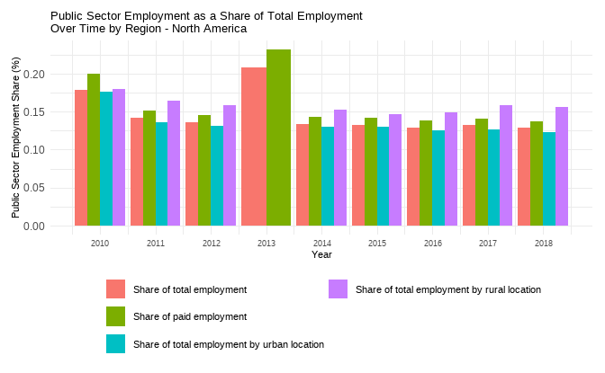

- Create a better comparison plots for the above criteria

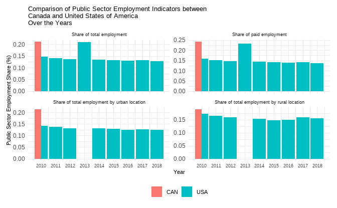

### Visualization for Question 2

The visualizations created to address question 2 are shown below.

- Create a visualization to show the relationship between Income Group and Public Administration Efficiency over years

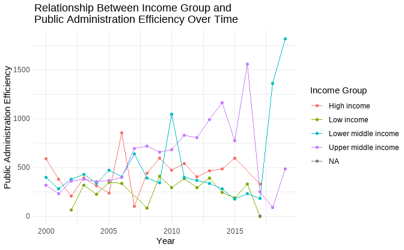

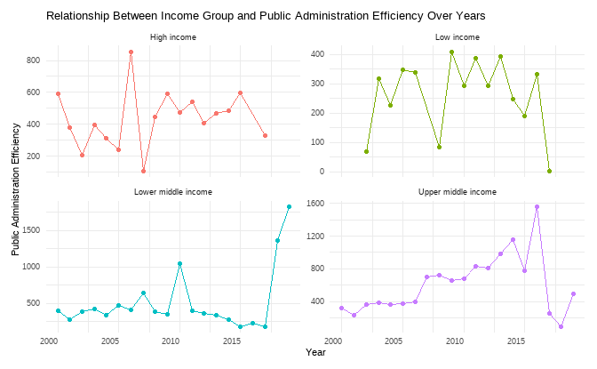

## References

Baig, Faisal Ali, Xu Han, Zahid Hasnain, and Daniel Rogger. 2021. “Introducing the Worldwide Bureaucracy Indicators: A New Global Dataset on Public Sector Employment and Compensation.” *Public Administration Review* 81 (3): 564–71.